# Lecture 10 Notes

Quantitative Data Analysis

# Introduction

- We have started to look at our model specification
- Last time, we concluded that a semi-log model was superior to the linear model we started with
- This time, we will refine our model and discuss more about the assumptions underlying what we are doing

# Assumptions

We will consider the following assumptions (taken from Peter Kennedy’s “A guide to econometrics”):

1. The model is correctly specified
2. The residuals have the same variance and are independent of one another
3. There are no exact linear relationships between independent variables
4. The independent variables are fixed and measured without error
5. The expected value of the residual is zero

# Refining our model

- I want us to start removing some irrelevant variables from our model to make it more tractable
- It is hard to tell what is irrelevant because we know that in a misspecified model we cannot trust the p-values
- This makes the process iterative
- It also means we have to use our domain knowledge, theory and previous work to guide the process

# Assumption 3

- The third assumption of the model can also make it hard to discern what variables are significant
- The formal assumption is that there is no exact linear relationship between our independent variables
- In this form, the assumption is not problematic
- We cannot estimate a model when we fail this assumption
- What it says is that we must not be able to derive one of our independent variables through any linear combination of the other independent variables

# Example

- Suppose we are studying food poverty and want to know the impact of income on a household’s expenditure on food
- Let’s say we have a household with two adults each of whom earns an income
- Suppose in our model we have three independent variables:
1. Income of Person A
2. Income of Person B
3. Total household income
- This violates the assumption because total household income is simply the sum of the incomes of Person A and Person B
- If we try to estimate this model, R will throw one of the variables out
- This problem is known as perfect multicollinearity

# Why is it this way?

- If you want to see why this makes the model impossible to estimate, you can try to solve the linear algebra behind the model
- Eventually you will have to divide by zero which you cannot do
- However, you may also be able to see intuitively why you cannot estimate separate effects
- For example, you cannot observe a household where both members have high income but the household has low income
- You cannot observe a household where both members have low income but the household has high income
- Without this ability, there is no way to estimate the individual contribution made by each variable

# A question of degree

- You will only violate this assumption if what you are trying to do does not make sense
- However, it is a question of degree
- The problem exists somewhat so long as our independent variables are correlated
- The higher the degree of correlation, the greater the multicollinearity problem

# Multicollinearity

- When we have a high degree of multicollinearity we may find problems
- Standard errors can be inflated, making our estimates less efficient and harder to find statistically significant coefficients
- We may also see variables with coefficients with incorrect signs
- Coefficient estimates may vary widely between different model specifications i.e., adding or dropping variables may lead to large changes in coefficient estimates

# Detecting multicollinearity

- Remember this is a question of degree
- We may have reasons *a priori* to suspect a correlation between independent variables
- We may see odd behaviour in the model e.g.,
- Large standard errors, particularly where we don’t expect them
- Unstable coefficients in our model
- We can inspect bivariate correlations between our variables
- We can use more sophisticated measures such as Variance Inflation Factors
- Multicollinearity isn’t a problem unless it is bothering you

# Variance Inflation Factors

- Variance inflation factors are based on trying to see how much of the variation in one of our independent variables can be explained by variation in the other independent variables
- The VIF shows us how much the variance of the coefficient estimate is being inflated by multicollinearity
- A value of 1 indicates no multicollinearity
- Anything under 5 would not cause concern
- If it goes over 10 we might be concerned
- So long as we have no symptoms, it isn’t a problem
- We can calculate (Generalised) VIFs using the *vif()* function from the *car* package

# VIFs from our model

```r
lfs %>% mutate(log_wage = log(HOURPAY)) %>%
  lm(log_wage ~ SEX + AGE + HIQUL22D + FLEX22W6 + FTPT + EMPLEN + JOBTYP + MPNR02 + MARSTA + INDE07M + NSECMJ20 + GOR9D,
     data=.) %>%
 vif()
```

```
##              GVIF Df GVIF^(1/(2*Df))
## SEX      1.249367  1        1.117751
## AGE      1.682555  1        1.297133
## HIQUL22D 1.609476  5        1.048741
## FLEX22W6 1.124745  1        1.060540
## FTPT     1.266411  1        1.125349
## EMPLEN   1.431578  7        1.025958
## JOBTYP   1.122614  1        1.059535
## MPNR02   1.269364  8        1.015019
## MARSTA   1.432800  5        1.036618
## INDE07M  1.668301  8        1.032505
## NSECMJ20 2.151890  6        1.065946
## GOR9D    1.190306 11        1.007950
```

# Interpretation

- In a model with factor variables, the scaled GVIF values (GVIF^(1/(2*Df))) are usually recommended
- There is no indication here that multicollinearity is a problem
- We shouldn’t see standard errors being inflated by multicollinearity

# Dealing with multicollinearity

- First ask yourself whether it needs to be dealt with
- You can consider dropping a variable, however if this causes an omitted variable problem then the cure is worse than the disease
- Consider some kind of data reduction e.g., factor analysis, principal components analysis
- This will make interpretation harder
- Use joint hypothesis tests i.e., test groups of coefficients instead of individual coefficients
- Some would suggest using a technique called ridge regression, but this gives biased estimates

# Assumption 4

- Assumption 4 makes some assumptions about our independent variables
- Part of this is assuming the independent variables are exogenous
- This is actually a very large topic but we will try to keep it simple
- We must be very careful about having the same variable appear on both the right and left sides of the regression equation e.g., body mass index expressed as a function of height
- We must avoid situations where the independent variable may depend on the dependent variable

# Assumption 4 and our model

- Diagnosing these problems is very complex
- The easiest way is to be reflective in your modelling and to use previous work and theory
- We don’t commit the issue of having wages on both the left and right of the regression equation
- Do we have any examples of an independent variable which is not exogenous e.g., might any of our independent variables be determined by wages?

# Our independent variables

- Age
- Full-time / Part-time
- Zero hours contract
- Permanent job
- Region
- Time with current employer
- Education
- Industry
- Job Type
- Marital status
- Firm size

# Problem

- I would suggest that *time with current employer* is problematic
- Our initial idea was that time spent with current employer may capture someone’s employment experience
- More experience may lead to higher wages
- However, if my current employer pays me well, then I may stay with them longer
- If my job doesn’t pay well, I might not stay around for long
- We may have an *endogenous* relationship in our model

# Solutions

- Dealing with endogenous variables can get very complicated
- I would suggest not specifying models with such relationships
- For our model, I am going to suggest excluding it
- We cannot know whether we can reliably interpret the results
- This applies both to the coefficients and the standard errors

# Refining our model

- Let’s return to our regression model
- We will begin by revising what we saw last time
- We begin with the linear model

# The original linear model

```
##
## Call:
## lm(formula = HOURPAY ~ SEX + AGE + HIQUL22D + FLEX22W6 + FTPT +
##     EMPLEN + JOBTYP + MPNR02 + MARSTA + INDE07M + NSECMJ20 +
##     GOR9D, data = .)
##
## Residuals:
##     Min      1Q  Median      3Q     Max
## -31.140  -5.101  -1.189   3.046  79.547
##
## Coefficients:
##                                                     Estimate Std. Error t value
## (Intercept)                                         25.78853    1.98215  13.010
## SEXFemale                                           -1.78189    0.23677  -7.526
## AGE                                                  0.10231    0.01142   8.956
## HIQUL22DHigher education                            -3.23076    0.42198  -7.656
## HIQUL22DA level or equivalent                       -3.85940    0.29611 -13.034
## HIQUL22DGCSE A*-C or equivalent                     -4.53640    0.34719 -13.066
## HIQUL22DOther qualitfication                        -4.44594    0.55803  -7.967
## HIQUL22DNo Qualification                            -6.14744    0.68828  -8.932
## FLEX22W6No                                           0.40302    0.78712   0.512
## FTPTPart-time                                       -0.07943    0.28902  -0.275
## EMPLENThree months, less than 6                     -0.39861    0.85519  -0.466
## EMPLEN6 months, less than 12                        -0.18981    0.78648  -0.241
## EMPLEN1 year, less than 2                           -0.30792    0.71735  -0.429
## EMPLEN2 years, less than 5                           0.34445    0.68859   0.500
## EMPLEN5 years, less than 10                          0.52264    0.70371   0.743
## EMPLEN10 years, less than 20                         1.06104    0.70594   1.503
## EMPLEN20 years or more                               1.57930    0.73389   2.152
## JOBTYPNot permanent in some way                      0.15802    0.62841   0.251
## MPNR0211-19                                          0.01830    0.46778   0.039
## MPNR0220-24                                          0.17017    0.60750   0.280
## MPNR02Don't know but under 25                       -1.01501    0.78914  -1.286
## MPNR0225-49                                          0.05431    0.41028   0.132
## MPNR0250-249                                         0.51390    0.35217   1.459
## MPNR02250-499                                        1.50815    0.50016   3.015
## MPNR02Don't know but between 50 and 499              0.65691    0.58493   1.123
## MPNR02500 or more                                    2.40393    0.35823   6.711
## MARSTAMarried, living with spouse                    1.44619    0.25735   5.620
## MARSTAMarried separated from spouse                  0.79898    0.73767   1.083
```

[output cut: 76 more lines]

```
## GOR9DWest Midlands                                 2.83e-09 ***
## GOR9DSouth East                                    2.62e-07 ***
## GOR9DEast of England                               2.99e-05 ***
## GOR9DEast Midlands                                 2.99e-14 ***
## GOR9DNorth East                                    2.19e-15 ***
## GOR9DNorth West                                    1.77e-14 ***
## GOR9DWales                                         8.65e-14 ***
## GOR9DNorthern Ireland                               < 2e-16 ***
## GOR9DScotland                                      6.57e-10 ***
## ---
## Signif. codes:  0 '***' 0.001 '**' 0.01 '*' 0.05 '.' 0.1 ' ' 1
##
## Residual standard error: 9.055 on 7291 degrees of freedom
## Multiple R-squared:  0.389,  Adjusted R-squared:  0.3844
## F-statistic: 84.41 on 55 and 7291 DF,  p-value: < 2.2e-16
```

# Residual versus fitted

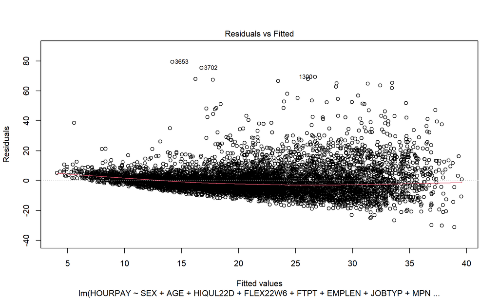

# QQ plot of residuals

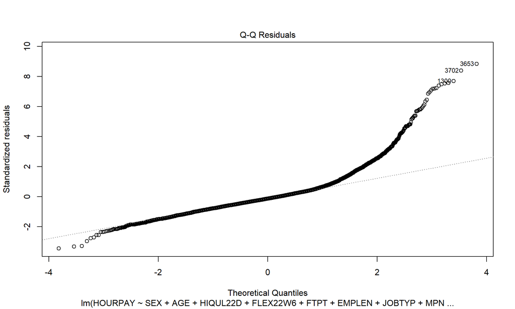

# The RESET test

```r
lfs %>%
  lm(HOURPAY ~ SEX + AGE + HIQUL22D + FLEX22W6 + FTPT + EMPLEN + JOBTYP + MPNR02 + MARSTA + INDE07M + NSECMJ20 + GOR9D, data=.) %>%
  resettest()
```

```
##
##  RESET test
##
## data:  .
## RESET = 123.33, df1 = 2, df2 = 7289, p-value < 2.2e-16
```

# The BP test

```r
lfs %>%
  lm(HOURPAY ~ SEX + AGE + HIQUL22D + FLEX22W6 + FTPT + EMPLEN + JOBTYP + MPNR02 + MARSTA + INDE07M + NSECMJ20 + GOR9D, data=.) %>%
  bptest()
```

```
##
##  studentized Breusch-Pagan test
##
## data:  .
## BP = 390.68, df = 55, p-value < 2.2e-16
```

# The semi-log model

- Our model isn’t meeting the assumptions
- Last time we improved the model by taking a log transformation

# The semi-log linear model

```
##
## Call:
## lm(formula = log_wage ~ SEX + AGE + HIQUL22D + FLEX22W6 + FTPT +
##     EMPLEN + JOBTYP + MPNR02 + MARSTA + INDE07M + NSECMJ20 +
##     GOR9D, data = .)
##
## Residuals:
##      Min       1Q   Median       3Q      Max
## -1.62055 -0.21109 -0.01861  0.19648  1.96285
##
## Coefficients:
##                                                      Estimate Std. Error
## (Intercept)                                         3.0115227  0.0744636
## SEXFemale                                          -0.0719738  0.0088949
## AGE                                                 0.0041173  0.0004292
## HIQUL22DHigher education                           -0.1352929  0.0158525
## HIQUL22DA level or equivalent                      -0.1692705  0.0111238
## HIQUL22DGCSE A*-C or equivalent                    -0.2011436  0.0130428
## HIQUL22DOther qualitfication                       -0.1975554  0.0209636
## HIQUL22DNo Qualification                           -0.2873597  0.0258566
## FLEX22W6No                                          0.0567135  0.0295696
## FTPTPart-time                                      -0.0297625  0.0108578
## EMPLENThree months, less than 6                    -0.0151183  0.0321268
## EMPLEN6 months, less than 12                        0.0146695  0.0295457
## EMPLEN1 year, less than 2                           0.0065315  0.0269487
## EMPLEN2 years, less than 5                          0.0477627  0.0258684
## EMPLEN5 years, less than 10                         0.0642989  0.0264364
## EMPLEN10 years, less than 20                        0.0872838  0.0265202
## EMPLEN20 years or more                              0.1164016  0.0275700
## JOBTYPNot permanent in some way                     0.0104594  0.0236075
## MPNR0211-19                                         0.0111125  0.0175732
## MPNR0220-24                                         0.0178841  0.0228220
## MPNR02Don't know but under 25                      -0.0260251  0.0296457
## MPNR0225-49                                         0.0139941  0.0154129
## MPNR0250-249                                        0.0441019  0.0132299
## MPNR02250-499                                       0.0889228  0.0187895
## MPNR02Don't know but between 50 and 499             0.0365645  0.0219740
## MPNR02500 or more                                   0.1195901  0.0134575
## MARSTAMarried, living with spouse                   0.0579014  0.0096678
## MARSTAMarried separated from spouse                 0.0358534  0.0277121
```

[output cut: 76 more lines]

```
## GOR9DWest Midlands                                  -5.474 4.55e-08 ***
## GOR9DSouth East                                     -5.051 4.49e-07 ***
## GOR9DEast of England                                -3.778 0.000159 ***
## GOR9DEast Midlands                                  -7.915 2.85e-15 ***
## GOR9DNorth East                                     -7.434 1.17e-13 ***
## GOR9DNorth West                                     -7.203 6.49e-13 ***
## GOR9DWales                                          -7.052 1.93e-12 ***
## GOR9DNorthern Ireland                               -8.385  < 2e-16 ***
## GOR9DScotland                                       -5.719 1.11e-08 ***
## ---
## Signif. codes:  0 '***' 0.001 '**' 0.01 '*' 0.05 '.' 0.1 ' ' 1
##
## Residual standard error: 0.3402 on 7291 degrees of freedom
## Multiple R-squared:  0.483,  Adjusted R-squared:  0.4791
## F-statistic: 123.9 on 55 and 7291 DF,  p-value: < 2.2e-16
```

# Residual versus fitted

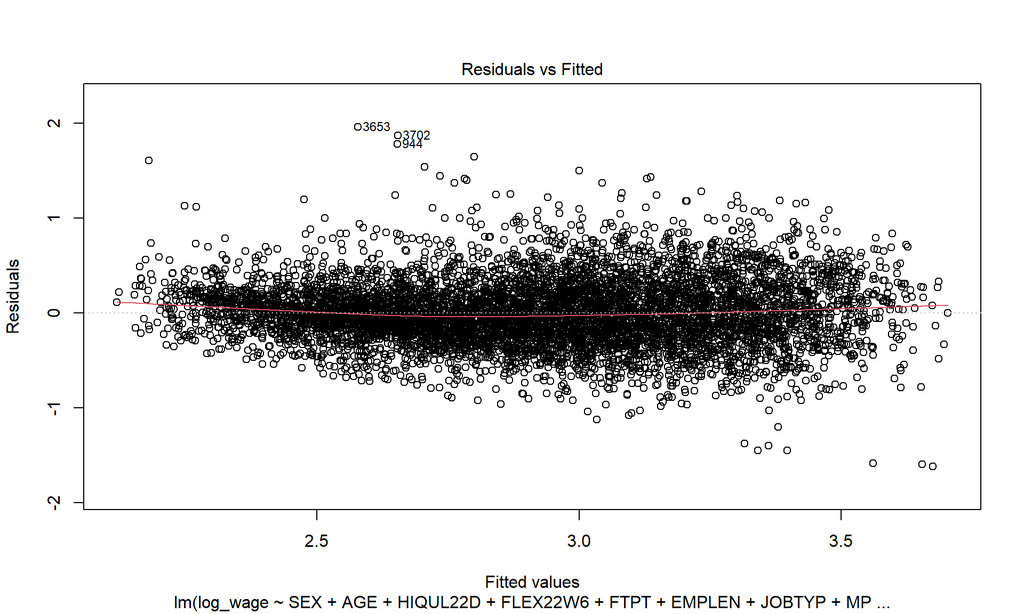

# QQ plot of residuals

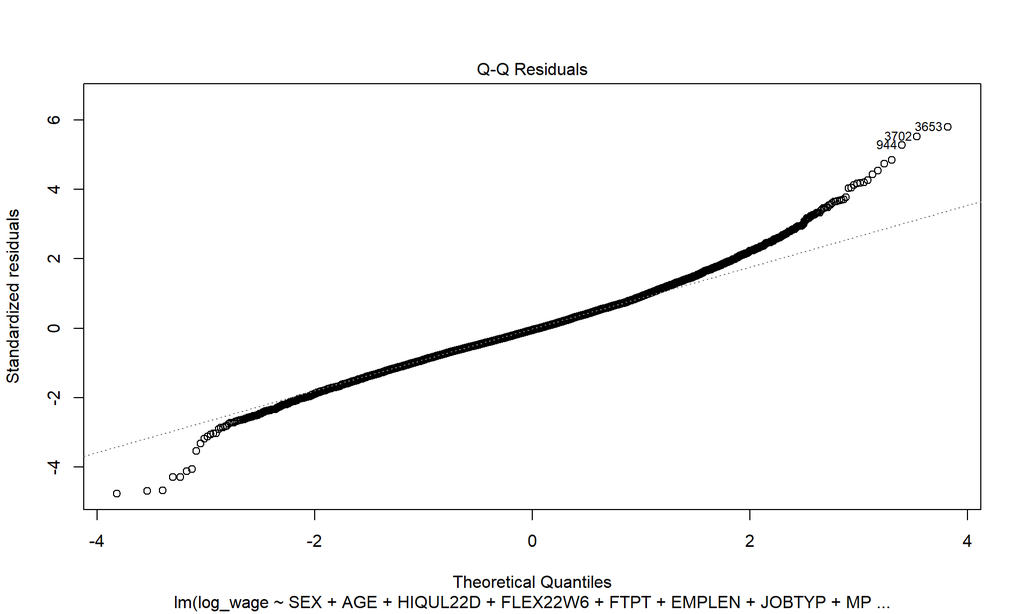

# The RESET test

```r
lfs %>%
  mutate(log_wage = log(HOURPAY)) %>%
  lm(log_wage ~ SEX + AGE + HIQUL22D + FLEX22W6 + FTPT + EMPLEN + JOBTYP + MPNR02 + MARSTA + INDE07M + NSECMJ20 + GOR9D, data=.)  %>%
  resettest()
```

```
##
##  RESET test
##
## data:  .
## RESET = 52.408, df1 = 2, df2 = 7289, p-value < 2.2e-16
```

# The BP test

```r
lfs %>%
  mutate(log_wage = log(HOURPAY)) %>%
  lm(log_wage ~ SEX + AGE + HIQUL22D + FLEX22W6 + FTPT + EMPLEN + JOBTYP + MPNR02 + MARSTA + INDE07M + NSECMJ20 + GOR9D, data=.)  %>%
  bptest()
```

```
##
##  studentized Breusch-Pagan test
##
## data:  .
## BP = 356.74, df = 55, p-value < 2.2e-16
```

# Thoughts

- The semi-log model is a substantial improvement
- It still isn’t formally meeting the assumptions
- This is probably as good as we can get it unless we bring in other variables
- Helpfully, the linear model is pretty robust to departures from the assumptions
- I think we can argue that our results are quite robust
- Let’s see if we can make any improvements and refinements

# Let’s ditch our endogenous variable (EMPLEN)

```
##
## Call:
## lm(formula = log_wage ~ SEX + AGE + HIQUL22D + FLEX22W6 + FTPT +
##     JOBTYP + MPNR02 + MARSTA + INDE07M + NSECMJ20 + GOR9D, data = .)
##
## Residuals:
##      Min       1Q   Median       3Q      Max
## -1.59585 -0.21204 -0.01958  0.19681  1.99143
##
## Coefficients:
##                                                      Estimate Std. Error
## (Intercept)                                         3.0076449  0.0705405
## SEXFemale                                          -0.0729905  0.0089255
## AGE                                                 0.0053555  0.0003982
## HIQUL22DHigher education                           -0.1304069  0.0158969
## HIQUL22DA level or equivalent                      -0.1641653  0.0111481
## HIQUL22DGCSE A*-C or equivalent                    -0.1955231  0.0130727
## HIQUL22DOther qualitfication                       -0.1946198  0.0210410
## HIQUL22DNo Qualification                           -0.2776273  0.0259223
## FLEX22W6No                                          0.0639224  0.0296268
## FTPTPart-time                                      -0.0293177  0.0109014
## JOBTYPNot permanent in some way                    -0.0186073  0.0233054
## MPNR0211-19                                         0.0116080  0.0176365
## MPNR0220-24                                         0.0142293  0.0229066
## MPNR02Don't know but under 25                      -0.0286165  0.0297474
## MPNR0225-49                                         0.0139333  0.0154756
## MPNR0250-249                                        0.0469975  0.0132730
## MPNR02250-499                                       0.0925272  0.0188567
## MPNR02Don't know but between 50 and 499             0.0343483  0.0220521
## MPNR02500 or more                                   0.1278302  0.0134699
## MARSTAMarried, living with spouse                   0.0582442  0.0096969
## MARSTAMarried separated from spouse                 0.0292286  0.0278073
## MARSTADivorced                                      0.0625229  0.0173478
## MARSTAWidowed                                       0.0242070  0.0411645
## MARSTACurrently or previously in civil partnership  0.0003256  0.0397911
## INDE07MEnergy and water                             0.1877995  0.0657630
## INDE07MManufacturing                                0.1205071  0.0612521
## INDE07MConstruction                                 0.1921047  0.0625760
## INDE07MDistribution, hotels and restaurants        -0.0113958  0.0606417
## INDE07MTransport and communication                  0.1670971  0.0611673
```

[output cut: 61 more lines]

```
## GOR9DWest Midlands                                  -5.371 8.08e-08 ***
## GOR9DSouth East                                     -4.976 6.65e-07 ***
## GOR9DEast of England                                -3.676 0.000239 ***
## GOR9DEast Midlands                                  -7.682 1.76e-14 ***
## GOR9DNorth East                                     -7.272 3.92e-13 ***
## GOR9DNorth West                                     -7.019 2.44e-12 ***
## GOR9DWales                                          -6.782 1.28e-11 ***
## GOR9DNorthern Ireland                               -7.757 9.91e-15 ***
## GOR9DScotland                                       -5.490 4.16e-08 ***
## ---
## Signif. codes:  0 '***' 0.001 '**' 0.01 '*' 0.05 '.' 0.1 ' ' 1
##
## Residual standard error: 0.3416 on 7298 degrees of freedom
## Multiple R-squared:  0.4782, Adjusted R-squared:  0.4748
## F-statistic: 139.4 on 48 and 7298 DF,  p-value: < 2.2e-16
```

# Residual versus fitted

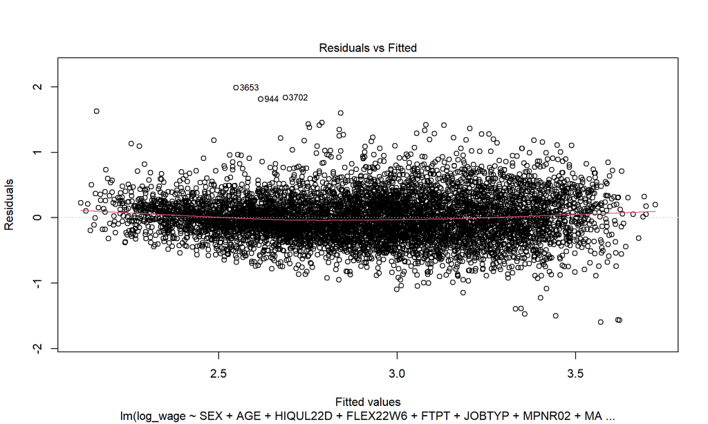

# QQ plot of residuals

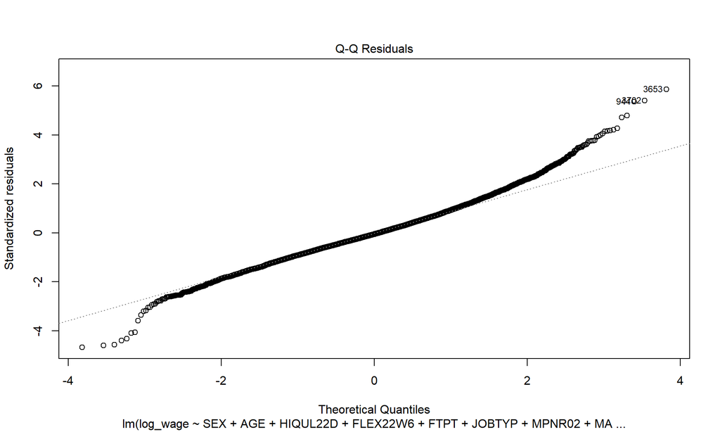

# The RESET test

```r
lfs %>%
  mutate(log_wage = log(HOURPAY)) %>%
  lm(log_wage ~ SEX + AGE + HIQUL22D + FLEX22W6 + FTPT + JOBTYP + MPNR02 + MARSTA + INDE07M + NSECMJ20 + GOR9D, data=.)  %>%
  resettest()
```

```
##
##  RESET test
##
## data:  .
## RESET = 52.253, df1 = 2, df2 = 7296, p-value < 2.2e-16
```

# The BP test

```r
lfs %>%
  mutate(log_wage = log(HOURPAY)) %>%
  lm(log_wage ~ SEX + AGE + HIQUL22D + FLEX22W6 + FTPT + JOBTYP + MPNR02 + MARSTA + INDE07M + NSECMJ20 + GOR9D, data=.)  %>%
  bptest()
```

```
##
##  studentized Breusch-Pagan test
##
## data:  .
## BP = 341.84, df = 48, p-value < 2.2e-16
```

# Our current model

```
##
## Call:
## lm(formula = log_wage ~ SEX + AGE + HIQUL22D + FLEX22W6 + FTPT +
##     JOBTYP + MPNR02 + MARSTA + INDE07M + NSECMJ20 + GOR9D, data = .)
##
## Residuals:
##      Min       1Q   Median       3Q      Max
## -1.59585 -0.21204 -0.01958  0.19681  1.99143
##
## Coefficients:
##                                                      Estimate Std. Error
## (Intercept)                                         3.0076449  0.0705405
## SEXFemale                                          -0.0729905  0.0089255
## AGE                                                 0.0053555  0.0003982
## HIQUL22DHigher education                           -0.1304069  0.0158969
## HIQUL22DA level or equivalent                      -0.1641653  0.0111481
## HIQUL22DGCSE A*-C or equivalent                    -0.1955231  0.0130727
## HIQUL22DOther qualitfication                       -0.1946198  0.0210410
## HIQUL22DNo Qualification                           -0.2776273  0.0259223
## FLEX22W6No                                          0.0639224  0.0296268
## FTPTPart-time                                      -0.0293177  0.0109014
## JOBTYPNot permanent in some way                    -0.0186073  0.0233054
## MPNR0211-19                                         0.0116080  0.0176365
## MPNR0220-24                                         0.0142293  0.0229066
## MPNR02Don't know but under 25                      -0.0286165  0.0297474
## MPNR0225-49                                         0.0139333  0.0154756
## MPNR0250-249                                        0.0469975  0.0132730
## MPNR02250-499                                       0.0925272  0.0188567
## MPNR02Don't know but between 50 and 499             0.0343483  0.0220521
## MPNR02500 or more                                   0.1278302  0.0134699
## MARSTAMarried, living with spouse                   0.0582442  0.0096969
## MARSTAMarried separated from spouse                 0.0292286  0.0278073
## MARSTADivorced                                      0.0625229  0.0173478
## MARSTAWidowed                                       0.0242070  0.0411645
## MARSTACurrently or previously in civil partnership  0.0003256  0.0397911
## INDE07MEnergy and water                             0.1877995  0.0657630
## INDE07MManufacturing                                0.1205071  0.0612521
## INDE07MConstruction                                 0.1921047  0.0625760
## INDE07MDistribution, hotels and restaurants        -0.0113958  0.0606417
## INDE07MTransport and communication                  0.1670971  0.0611673
```

[output cut: 61 more lines]

```
## GOR9DWest Midlands                                  -5.371 8.08e-08 ***
## GOR9DSouth East                                     -4.976 6.65e-07 ***
## GOR9DEast of England                                -3.676 0.000239 ***
## GOR9DEast Midlands                                  -7.682 1.76e-14 ***
## GOR9DNorth East                                     -7.272 3.92e-13 ***
## GOR9DNorth West                                     -7.019 2.44e-12 ***
## GOR9DWales                                          -6.782 1.28e-11 ***
## GOR9DNorthern Ireland                               -7.757 9.91e-15 ***
## GOR9DScotland                                       -5.490 4.16e-08 ***
## ---
## Signif. codes:  0 '***' 0.001 '**' 0.01 '*' 0.05 '.' 0.1 ' ' 1
##
## Residual standard error: 0.3416 on 7298 degrees of freedom
## Multiple R-squared:  0.4782, Adjusted R-squared:  0.4748
## F-statistic: 139.4 on 48 and 7298 DF,  p-value: < 2.2e-16
```

# Part-time and zero-hours contracts

# Refined model

```
##
## Call:
## lm(formula = log_wage ~ SEX + AGE + HIQUL22D + FTPT + JOBTYP +
##     MPNR02 + MARSTA + INDE07M + NSECMJ20 + GOR9D, data = .)
##
## Residuals:
##      Min       1Q   Median       3Q      Max
## -1.59664 -0.21275 -0.01911  0.19687  1.99620
##
## Coefficients:
##                                                      Estimate Std. Error
## (Intercept)                                         3.0697098  0.0644249
## SEXFemale                                          -0.0728093  0.0089273
## AGE                                                 0.0053838  0.0003981
## HIQUL22DHigher education                           -0.1308017  0.0158998
## HIQUL22DA level or equivalent                      -0.1639414  0.0111504
## HIQUL22DGCSE A*-C or equivalent                    -0.1947025  0.0130705
## HIQUL22DOther qualitfication                       -0.1938950  0.0210435
## HIQUL22DNo Qualification                           -0.2763608  0.0259222
## FTPTPart-time                                      -0.0312090  0.0108688
## JOBTYPNot permanent in some way                    -0.0285256  0.0228532
## MPNR0211-19                                         0.0115431  0.0176409
## MPNR0220-24                                         0.0139960  0.0229121
## MPNR02Don't know but under 25                      -0.0295990  0.0297514
## MPNR0225-49                                         0.0139838  0.0154794
## MPNR0250-249                                        0.0473970  0.0132750
## MPNR02250-499                                       0.0934217  0.0188569
## MPNR02Don't know but between 50 and 499             0.0333879  0.0220531
## MPNR02500 or more                                   0.1287248  0.0134669
## MARSTAMarried, living with spouse                   0.0585553  0.0096983
## MARSTAMarried separated from spouse                 0.0284295  0.0278118
## MARSTADivorced                                      0.0624700  0.0173522
## MARSTAWidowed                                       0.0246423  0.0411744
## MARSTACurrently or previously in civil partnership -0.0001658  0.0398004
## INDE07MEnergy and water                             0.1880907  0.0657794
## INDE07MManufacturing                                0.1211473  0.0612667
## INDE07MConstruction                                 0.1931411  0.0625899
## INDE07MDistribution, hotels and restaurants        -0.0119765  0.0606563
## INDE07MTransport and communication                  0.1677362  0.0611819
## INDE07MBanking and finance                          0.1194270  0.0605224
```

[output cut: 59 more lines]

```
## GOR9DWest Midlands                                  -5.379 7.72e-08 ***
## GOR9DSouth East                                     -5.017 5.37e-07 ***
## GOR9DEast of England                                -3.721 0.000200 ***
## GOR9DEast Midlands                                  -7.689 1.68e-14 ***
## GOR9DNorth East                                     -7.274 3.85e-13 ***
## GOR9DNorth West                                     -7.010 2.60e-12 ***
## GOR9DWales                                          -6.785 1.26e-11 ***
## GOR9DNorthern Ireland                               -7.745 1.09e-14 ***
## GOR9DScotland                                       -5.514 3.63e-08 ***
## ---
## Signif. codes:  0 '***' 0.001 '**' 0.01 '*' 0.05 '.' 0.1 ' ' 1
##
## Residual standard error: 0.3417 on 7299 degrees of freedom
## Multiple R-squared:  0.4779, Adjusted R-squared:  0.4745
## F-statistic: 142.1 on 47 and 7299 DF,  p-value: < 2.2e-16
```

# Marital status

- Marital status seems to be important, however only two categories are significant: *married and living with spouse* and *divorced*
- We could consider reducing this to two levels
- There are various ways of achieving this
- I’m going to use the *case_when* function
- Then we will re-run our regression

# Creating a new variable

```r
lfs <- lfs %>%
  mutate(new_MARSTA = case_when(
    MARSTA == "Married, living with spouse" ~ "Married",
    MARSTA == "Divorced" ~ "Divorced",
    TRUE ~ "Other") %>%
      factor() %>%
      relevel(ref = "Other")
    )
```

# Changing the reference level for industry

- We noted that our reference category for industry is the smallest industry
- Let’s make the largest industry the reference category

```r
lfs <- lfs %>%
  mutate(INDE07M = relevel(INDE07M, ref = "Public admin, education and health"))
```

# Changing the age variable to a categorical variable

- To allow for more nonlinear effects, we can use the 5-year age groups from the data set
- We have to modify our existing script to add in the AGES variable
- We could use a more detailed grouping, but this is already quite detailed

# Refined model

```
##
## Call:
## lm(formula = log_wage ~ SEX + AGES + HIQUL22D + FTPT + JOBTYP +
##     MPNR02 + new_MARSTA + INDE07M + NSECMJ20 + GOR9D, data = .)
##
## Residuals:
##      Min       1Q   Median       3Q      Max
## -1.59477 -0.21330 -0.01482  0.19322  1.97498
##
## Coefficients:
##                                              Estimate Std. Error t value
## (Intercept)                                  3.071377   0.040801  75.276
## SEXFemale                                   -0.077926   0.008856  -8.799
## AGES20-24 years                              0.029881   0.037176   0.804
## AGES25-29 years                              0.113455   0.036701   3.091
## AGES30-34 years                              0.210264   0.036244   5.801
## AGES35-39 years                              0.269129   0.036544   7.365
## AGES40-44 years                              0.293082   0.036508   8.028
## AGES45-49 years                              0.319701   0.036825   8.682
## AGES50-54 years                              0.316385   0.036721   8.616
## AGES55-59 years                              0.333609   0.036765   9.074
## AGES60-64 years                              0.270392   0.037477   7.215
## HIQUL22DHigher education                    -0.124200   0.015773  -7.874
## HIQUL22DA level or equivalent               -0.153325   0.011123 -13.784
## HIQUL22DGCSE A*-C or equivalent             -0.189458   0.013051 -14.517
## HIQUL22DOther qualitfication                -0.201310   0.020865  -9.648
## HIQUL22DNo Qualification                    -0.275918   0.025699 -10.737
## FTPTPart-time                               -0.025525   0.010832  -2.356
## JOBTYPNot permanent in some way             -0.019869   0.022661  -0.877
## MPNR0211-19                                  0.015408   0.017492   0.881
## MPNR0220-24                                  0.014779   0.022719   0.651
## MPNR02Don't know but under 25               -0.025067   0.029505  -0.850
## MPNR0225-49                                  0.010905   0.015348   0.711
## MPNR0250-249                                 0.042461   0.013159   3.227
## MPNR02250-499                                0.090216   0.018693   4.826
## MPNR02Don't know but between 50 and 499      0.031594   0.021870   1.445
## MPNR02500 or more                            0.123912   0.013347   9.284
## new_MARSTADivorced                           0.048774   0.016814   2.901
## new_MARSTAMarried                            0.033619   0.009318   3.608
## INDE07MAgriculture, forestry and fishing    -0.010590   0.059719  -0.177
```

[output cut: 69 more lines]

```
## GOR9DWest Midlands                          4.59e-08 ***
## GOR9DSouth East                             2.14e-06 ***
## GOR9DEast of England                        0.000306 ***
## GOR9DEast Midlands                          2.21e-14 ***
## GOR9DNorth East                             5.24e-14 ***
## GOR9DNorth West                             2.05e-12 ***
## GOR9DWales                                  4.16e-12 ***
## GOR9DNorthern Ireland                       3.35e-14 ***
## GOR9DScotland                               1.64e-07 ***
## ---
## Signif. codes:  0 '***' 0.001 '**' 0.01 '*' 0.05 '.' 0.1 ' ' 1
##
## Residual standard error: 0.3385 on 7294 degrees of freedom
## Multiple R-squared:  0.4878, Adjusted R-squared:  0.4842
## F-statistic: 133.6 on 52 and 7294 DF,  p-value: < 2.2e-16
```

# Residual versus fitted

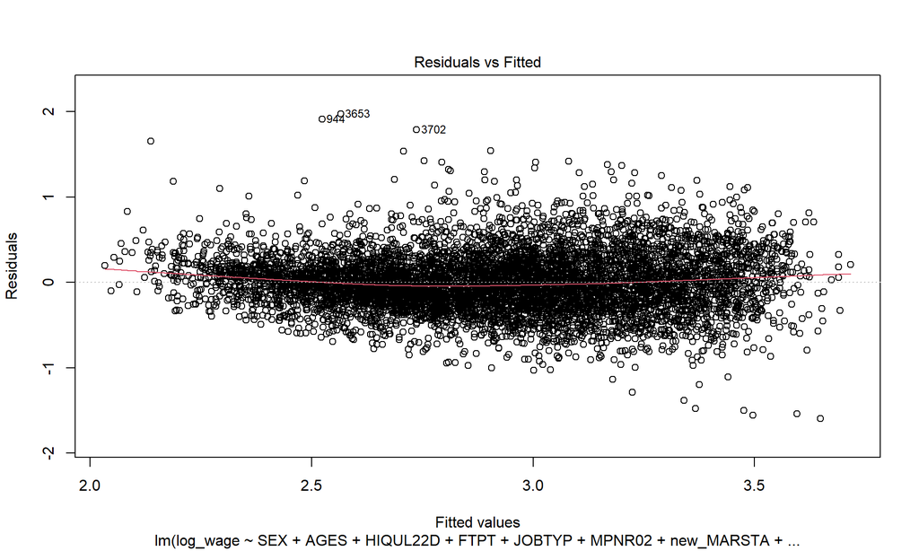

# QQ plot of residuals

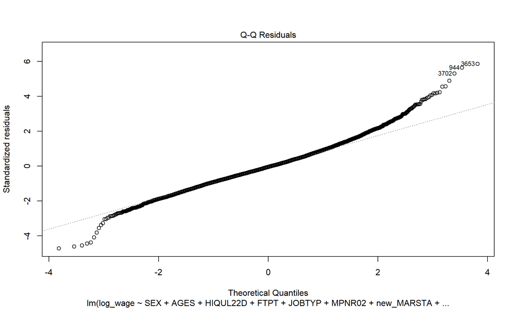

# The RESET test

```r
lfs %>%
  mutate(log_wage = log(HOURPAY)) %>%
  lm(log_wage ~ SEX + AGES + HIQUL22D + FTPT + JOBTYP + MPNR02 + new_MARSTA + INDE07M + NSECMJ20 + GOR9D, data=.) %>%
  resettest()
```

```
##
##  RESET test
##
## data:  .
## RESET = 90.25, df1 = 2, df2 = 7292, p-value < 2.2e-16
```

# The BP test

```r
lfs %>%
  mutate(log_wage = log(HOURPAY)) %>%
  lm(log_wage ~ SEX + AGES + HIQUL22D + FTPT + JOBTYP + MPNR02 + new_MARSTA + INDE07M + NSECMJ20 + GOR9D, data=.)  %>%
  bptest()
```

```
##
##  studentized Breusch-Pagan test
##
## data:  .
## BP = 331.69, df = 52, p-value < 2.2e-16
```

# Heteroscedasticity

- There is less of a heteroscedasticity problem in our refined model
- However, it is still there
- We had reason *a priori* to expect heteroscedasticity
- At this stage, I would suggest we make the necessary adjustments

# Derivation of the OLS estimators

- We saw in a previous lecture the basics of how the OLS estimator is derived
- Assume $X$ is a matrix of explanatory variables, $y$ is a vector of observed values of our dependent variable and $u$ is a vector of residuals
- We can derive $\beta = (X'X)^{-1}X'y$
- We also have to derive the standard errors of the $\beta$ parameters

# Derivation of the standard errors

- We won’t go through the full derivation
- At one stage in the derivation, we arrive at an expression for the standard errors: $E[(\hat{\beta}-\beta)(\hat{\beta}-\beta)'] = (X'X)^{-1}X'E[uu']X(X'X)^{-1}$
- We assume that the variance of the residuals is constant i.e, $E[uu']=\sigma^2I$
- This allows us to simplify our calculation of the standard errors to $\sigma^2(X'X)^{-1}$
- When we have heteroscedasticity $E[uu'] \neq \sigma^2I$, so we have to say something about what it does equal

# Robust standard errors

- Various suggestions have been made about how the standard errors should be calculated
- We won’t concern ourselves with the details; in practice in tends not to make a great deal of difference
- There are different options about how to implement this in R
- I will suggest using the *coeftest()* function from the *lmtest* package and the *vcovHC()* function from the *sandwich* package

# Robust standard errors

```r
lfs %>%
  mutate(log_wage = log(HOURPAY)) %>%
  lm(log_wage ~ SEX + AGES + HIQUL22D + FTPT + JOBTYP + MPNR02 + new_MARSTA + INDE07M + NSECMJ20 + GOR9D, data=.) %>%
coeftest(., vcov = vcovHC(.))
```

```
##
## t test of coefficients:
##
##                                               Estimate Std. Error  t value
## (Intercept)                                  3.0713766  0.0413786  74.2262
## SEXFemale                                   -0.0779263  0.0090922  -8.5707
## AGES20-24 years                              0.0298814  0.0345236   0.8655
## AGES25-29 years                              0.1134549  0.0353139   3.2128
## AGES30-34 years                              0.2102643  0.0351979   5.9738
## AGES35-39 years                              0.2691287  0.0356396   7.5514
## AGES40-44 years                              0.2930818  0.0355250   8.2500
## AGES45-49 years                              0.3197014  0.0358861   8.9088
## AGES50-54 years                              0.3163846  0.0357728   8.8443
## AGES55-59 years                              0.3336090  0.0358905   9.2952
## AGES60-64 years                              0.2703918  0.0367223   7.3632
## HIQUL22DHigher education                    -0.1242005  0.0158922  -7.8152
## HIQUL22DA level or equivalent               -0.1533249  0.0111090 -13.8018
## HIQUL22DGCSE A*-C or equivalent             -0.1894577  0.0126873 -14.9329
## HIQUL22DOther qualitfication                -0.2013098  0.0206791  -9.7349
## HIQUL22DNo Qualification                    -0.2759178  0.0220550 -12.5104
## FTPTPart-time                               -0.0255251  0.0111016  -2.2992
## JOBTYPNot permanent in some way             -0.0198692  0.0236420  -0.8404
## MPNR0211-19                                  0.0154079  0.0184774   0.8339
## MPNR0220-24                                  0.0147793  0.0230963   0.6399
## MPNR02Don't know but under 25               -0.0250670  0.0251590  -0.9963
## MPNR0225-49                                  0.0109053  0.0155900   0.6995
## MPNR0250-249                                 0.0424610  0.0137964   3.0777
## MPNR02250-499                                0.0902157  0.0190852   4.7270
## MPNR02Don't know but between 50 and 499      0.0315939  0.0228661   1.3817
## MPNR02500 or more                            0.1239118  0.0143013   8.6644
## new_MARSTADivorced                           0.0487740  0.0169955   2.8698
## new_MARSTAMarried                            0.0336194  0.0092442   3.6368
## INDE07MAgriculture, forestry and fishing    -0.0105899  0.0647676  -0.1635
## INDE07MEnergy and water                      0.1630855  0.0297111   5.4890
## INDE07MManufacturing                         0.1051048  0.0151844   6.9219
## INDE07MConstruction                          0.1710705  0.0214098   7.9903
## INDE07MDistribution, hotels and restaurants -0.0260650  0.0125052  -2.0843
## INDE07MTransport and communication           0.1448735  0.0167413   8.6536
## INDE07MBanking and finance                   0.1002843  0.0128046   7.8319
## INDE07MOther services                       -0.0252120  0.0221979  -1.1358
```

[output cut: 58 more lines]

```
## NSECMJ20Routine occupations                 < 2.2e-16 ***
## NSECMJ20Never worked                        < 2.2e-16 ***
## GOR9DYorkshire and The Humber               2.204e-13 ***
## GOR9DSouth West                             1.487e-09 ***
## GOR9DWest Midlands                          8.350e-07 ***
## GOR9DSouth East                             3.648e-05 ***
## GOR9DEast of England                         0.001056 **
## GOR9DEast Midlands                          2.399e-12 ***
## GOR9DNorth East                             6.688e-15 ***
## GOR9DNorth West                             7.987e-11 ***
## GOR9DWales                                  1.026e-12 ***
## GOR9DNorthern Ireland                       1.316e-13 ***
## GOR9DScotland                               1.939e-06 ***
## ---
## Signif. codes:  0 '***' 0.001 '**' 0.01 '*' 0.05 '.' 0.1 ' ' 1
```

# Thoughts

- We should check to see that the statistical significance of variables in our model have not changed
- It might be the case that we now wish to exclude some variables
- In this case, it hasn’t made much difference
- However, it is still important to check and to present the robust standard errors so that we can trust our results

# Check for multicollinearity

```
##                GVIF Df GVIF^(1/(2*Df))
## SEX        1.250493  1        1.118255
## AGES       1.923292  9        1.037004
## HIQUL22D   1.635433  5        1.050421
## FTPT       1.272717  1        1.128148
## JOBTYP     1.044482  1        1.021999
## MPNR02     1.256183  8        1.014357
## new_MARSTA 1.361966  2        1.080293
## INDE07M    1.671391  8        1.032624
## NSECMJ20   2.352050  6        1.073875
## GOR9D      1.174285 11        1.007329
```

# Check for outliers

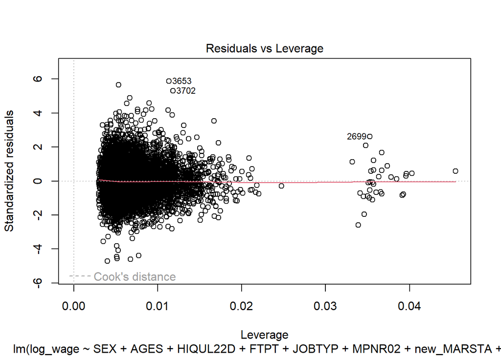

# Summary

- Our model is better than it was
- I suspect this is as good as we are likely to get the model
- I suggest that it is good enough
- Next time we will discuss some of the remaining assumptions